# **EP11: Regresión Lineal Múltiple**

2022-11-18

Un estudio recolectó medidas anatómicas de 247 hombres y 260 mujeres (Heinz et al., 2003). El estudio incluyó nueve mediciones del esqueleto (ocho diámetros y una profundidad de hueso a hueso) y doce mediciones de grosor (circunferencias) que incluyen el tejido.

# Carga de paquetes

```r
library("tidyverse")
library("ggpubr")
library("car")
library("caret")
```

# Carga de Datos

```r
# Se carga el archivo de datos EP11 Datos.csv
datos <- read.csv2("EP11 Datos.csv", fileEncoding = "UTF-8")
# datos
```

**1. Definir la semilla a utilizar, que corresponde a los últimos cuatro dígitos del RUN (sin considerar el dígito verificador) del integrante de menor edad del equipo.**

**2. Seleccionar una muestra de 50 mujeres (si la semilla es un número par) o 50 hombres (si la semilla es impar).**

**3. Seleccionar de forma aleatoria ocho posibles variables predictoras.**

```r
# Se carga la semilla considerando el rut del integrante con menor edad
set.seed(1914)
# Se filtran los datos para solo tener datos de mujeres
datos_mujeres <- datos %>% filter(Gender == 0)
# Se obtiene una muestra de 50 mujeres aleatorias
datos_mujeres <- sample_n(datos_mujeres, 50)
# Se guarda los valores de la variable de respuesta (peso)
Peso <- datos_mujeres$"Weight"
# Se excluye al peso para obtener 8 nuevas variables predictoras
datos_mujeres$"Weight" <- NULL
# Se obtienen las variables predictoras de forma aleatoria
variables_seleccionadas <- sample(colnames(datos_mujeres),8)
# Se obtienen las variables predictoras restantes
datos_rlm <- datos_mujeres %>% select(variables_seleccionadas)
```

```
## Note: Using an external vector in selections is ambiguous.
## i Use `all_of(variables_seleccionadas)` instead of `variables_seleccionadas` to silence this message.
## i See <https://tidyselect.r-lib.org/reference/faq-external-vector.html>.
```

```r
variables_seleccionadas
```

```
## [1] "Calf.Maximum.Girth"  "Chest.depth"         "Wrist.Minimum.Girth"
## [4] "Shoulder.Girth"      "Waist.Girth"         "Knee.Girth"
## [7] "Ankles.diameter"     "Bicep.Girth"
```

**4. Seleccionar, de las otras variables, una que el equipo considere que podría ser útil para predecir la variable Peso, justificando bien esta selección.**

```r
# Se obtienen los datos sin considerar las variables seleccionadas en el punto 3
variables_restantes <- datos_mujeres %>% select(!variables_seleccionadas)
# Se imprimen los nombres de las variables de los datos anteriores
print(colnames(variables_restantes))
```

```
##  [1] "Biacromial.diameter"     "Biiliac.diameter"
##  [3] "Bitrochanteric.diameter" "Chest.diameter"
##  [5] "Elbows.diameter"         "Wrists.diameter"
##  [7] "Knees.diameter"          "Chest.Girth"
##  [9] "Navel.Girth"             "Hip.Girth"
## [11] "Thigh.Girth"             "Forearm.Girth"
## [13] "Ankle.Minimum.Girth"     "Age"
## [15] "Height"                  "Gender"
```

```r
# Se calcula la correlación entre los datos restantes y el peso
correlacion <- cor(variables_restantes, y = Peso)
correlacion
```

```
##                               [,1]
## Biacromial.diameter     0.31234727
## Biiliac.diameter        0.55491808
## Bitrochanteric.diameter 0.77130006
## Chest.diameter          0.58889795
## Elbows.diameter         0.67620049
## Wrists.diameter         0.60140755
## Knees.diameter          0.82256212
## Chest.Girth             0.83396679
## Navel.Girth             0.76811595
## Hip.Girth               0.92229900
## Thigh.Girth             0.90497356
## Forearm.Girth           0.84074406
## Ankle.Minimum.Girth     0.71952285
## Age                     0.07464678
## Height                  0.25305431
## Gender                          NA
```

```r
# Se crea un dataframe con las variables restantes y el peso
datos_rls <- data.frame(variables_restantes, Peso)
```

**5. Usando el entorno R, construir un modelo de regresión lineal simple con el predictor seleccionado en el paso anterior.**

Utilizando la función **lm**, se creará un Modelo de Regresión Lineal. Utilizando la función **summary** se puede obtener información util sobre el modelo.

```r
#Se crea el modelo de regresión lineal
modelo_rls = lm(Peso ~ Hip.Girth, datos_mujeres)
#Se obtiene información del modelo
print(summary(modelo_rls))
```

```
##
## Call:
## lm(formula = Peso ~ Hip.Girth, data = datos_mujeres)
##
## Residuals:
##     Min      1Q  Median      3Q     Max
## -8.8244 -2.6143  0.0329  2.9873  9.7876
##
## Coefficients:
##              Estimate Std. Error t value Pr(>|t|)
## (Intercept) -61.44800    7.35420  -8.355 6.43e-11 ***
## Hip.Girth     1.27860    0.07733  16.534  < 2e-16 ***
## ---
## Signif. codes:  0 '***' 0.001 '**' 0.01 '*' 0.05 '.' 0.1 ' ' 1
##
## Residual standard error: 3.551 on 48 degrees of freedom
## Multiple R-squared:  0.8506, Adjusted R-squared:  0.8475
## F-statistic: 273.4 on 1 and 48 DF,  p-value: < 2.2e-16
```

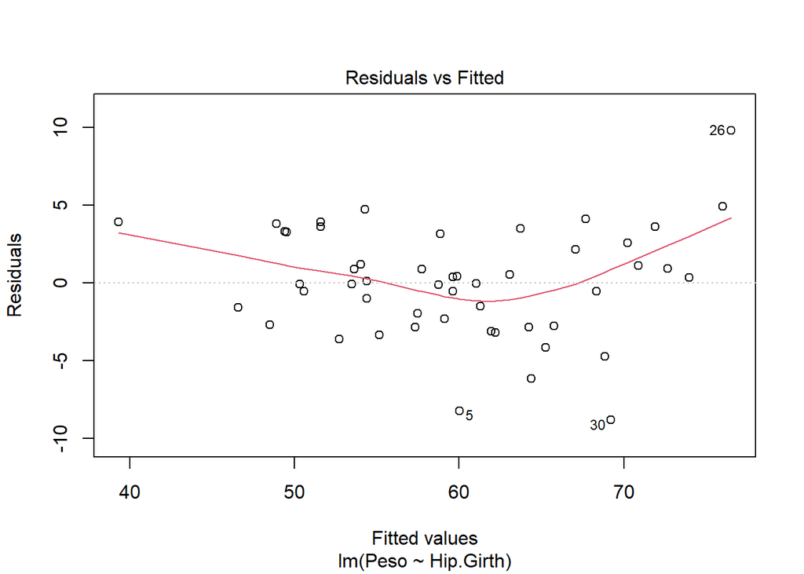

```r
# Se grafican los residuos del modelo
plot(modelo_rls, which = 1)
```

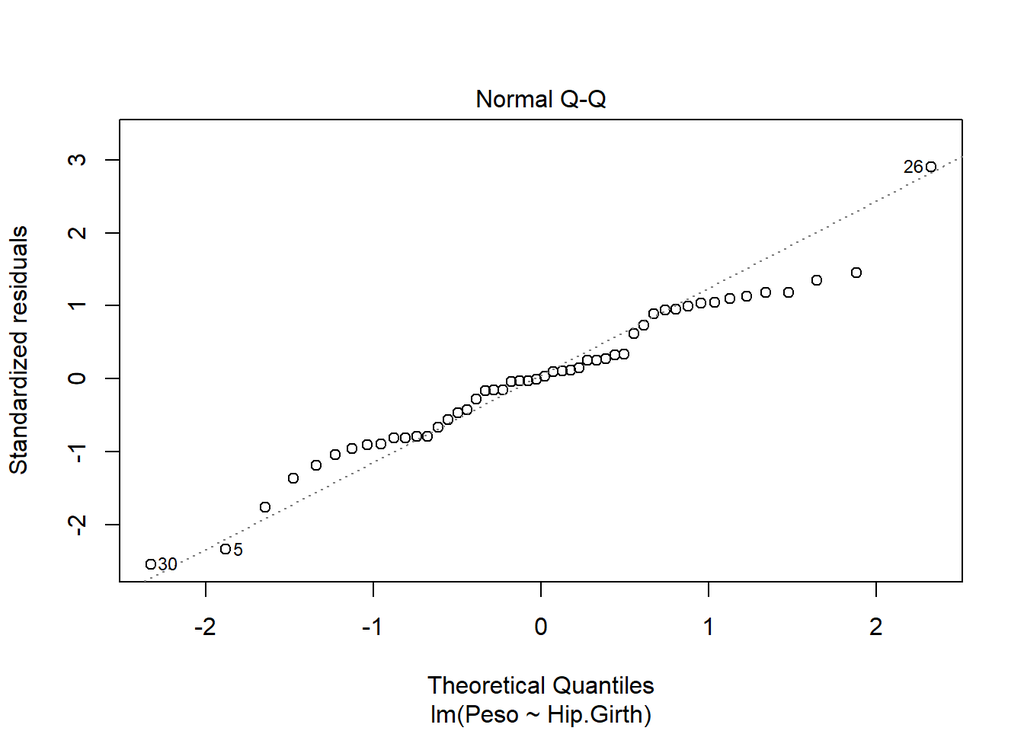

```r
# Se grafica el qq-plot de los datos del modelo
plot(modelo_rls, which = 2)
```

Ahora, podemos graficar el Modelo de Regresión Lineal creado. **Se muestra la regresión lineal para el Peso de acuerdo al Grosor a la altura de las caderas(Hip.Girth)**

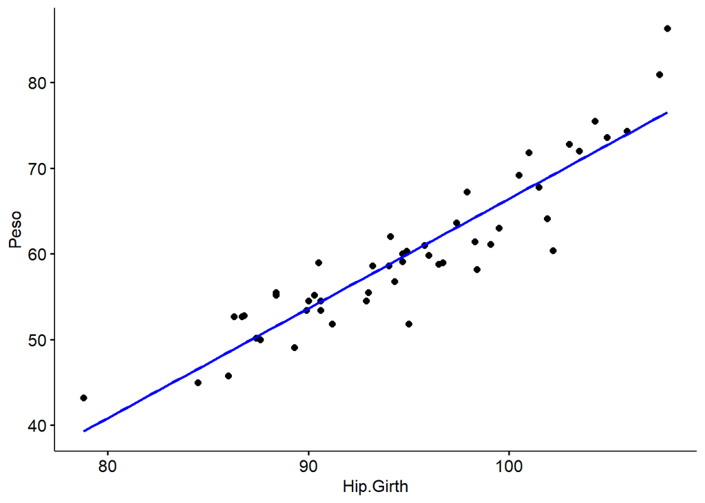

```r
# Se grafica el modelo
p <- ggscatter(datos_rls, x = "Hip.Girth", y = "Peso")
p <- p + geom_smooth(method = lm, se = FALSE, colour = "blue")
print(p)
```

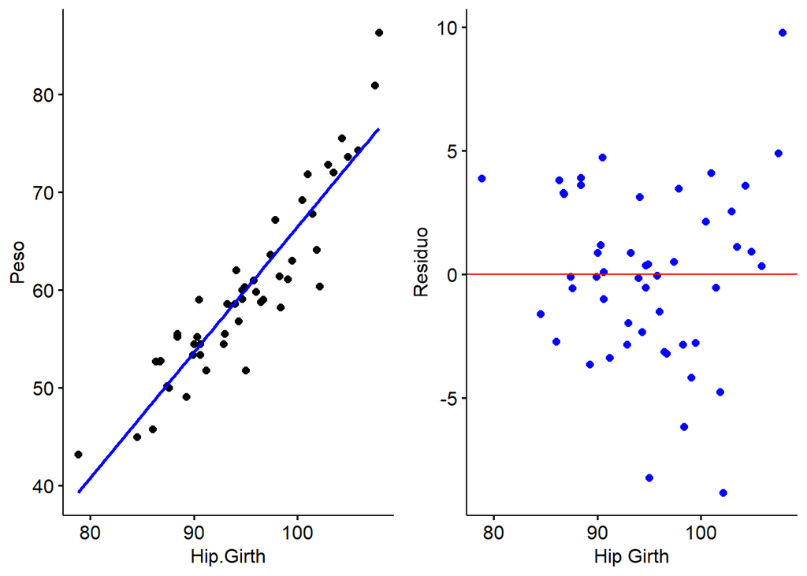

```r
# Graficar residuos
b_1 <- modelo_rls$coefficients[2]
b_0 <- modelo_rls$coefficients[1]
residuos <- datos_rls$Peso - (b_1 * datos_rls$Hip.Girth + b_0)
data_rls <- data.frame(residuos, datos_rls)

r <- ggscatter(data_rls, x = "Hip.Girth", y = "residuos", color = "blue", fill = "blue", xlab = "Hip Girth", ylab = "Residuo")
r <- r + geom_hline(yintercept = 0, colour = "red")
g <- ggarrange(p, r, ncol = 2, nrow = 1)
print(g)
```

```r
cat("Prueba de normalidad para residuos")
```

```
## Prueba de normalidad para residuos
```

```r
print(shapiro.test(data_rls$residuos))
```

```
##
##  Shapiro-Wilk normality test
##
## data:  data_rls$residuos
## W = 0.97537, p-value = 0.377
```

Cómo se puede observar mediante la prueba de Shapiro-Wilk a los residuos, concluimos que estos siguen una distribución normal (p = 0.377), también la variabilidad de residuos es constante, otra observación importante es que las observaciones han sido seleccionadas de manera aleatoria y pertenecen a menos del 10% de la población.

**6. Usando herramientas para la exploración de modelos del entorno R, buscar entre dos y cinco predictores de entre las variables seleccionadas al azar en el punto 3, para agregar al modelo de regresión lineal simple obtenido en el paso 5**

### Ajustar modelo completo

```r
nulo <- lm(Peso ~ 1, datos_rlm)
completo <- lm(Peso ~ ., datos_rlm)
print(add1(nulo, scope = completo))
```

```
## Single term additions
##
## Model:
## Peso ~ 1
##                     Df Sum of Sq    RSS    AIC
## <none>                           4051.6 221.74
## Calf.Maximum.Girth   1   2779.89 1271.7 165.80
## Chest.depth          1   1105.80 2945.8 207.81
## Wrist.Minimum.Girth  1   2247.06 1804.5 183.30
## Shoulder.Girth       1   2661.44 1390.1 170.26
## Waist.Girth          1   3041.20 1010.4 154.30
## Knee.Girth           1   2794.64 1256.9 165.22
## Ankles.diameter      1    926.99 3124.6 210.75
## Bicep.Girth          1   2484.79 1566.8 176.24
```

Cómo se puede observar en los AIC, se seleccionan 3 predictores con menor AIC, en este caso **Waist.Girth**, **Calf.Maximum.Girth** y **Knee.Girth**.

Se agregan las variables con menor AIC

```r
modelo <- update(modelo_rls, . ~ . + Waist.Girth + Calf.Maximum.Girth + Knee.Girth)
modelo
```

```
##
## Call:
## lm(formula = Peso ~ Hip.Girth + Waist.Girth + Calf.Maximum.Girth +
##     Knee.Girth, data = datos_mujeres)
##
## Coefficients:
##        (Intercept)           Hip.Girth         Waist.Girth  Calf.Maximum.Girth
##           -64.7587              0.4764              0.4559              0.6145
##         Knee.Girth
##             0.7555
```

#### Verificación de las condiciones

```r
alfa <- 0.05
# Independencia de los residuos
cat("Prueba de Dubin-Watson para autocorrelaciones entre errores:\n")
```

```
## Prueba de Dubin-Watson para autocorrelaciones entre errores:
```

```r
print(durbinWatsonTest(modelo))
```

```
##  lag Autocorrelation D-W Statistic p-value
##    1      0.06073576      1.826599    0.54
##  Alternative hypothesis: rho != 0
```

```r
# Distribución normal de los residuos
cat("\nPrueba de normalidad para residuos:\n")
```

```
##
## Prueba de normalidad para residuos:
```

```r
print(shapiro.test(modelo$residuals))
```

```
##
##  Shapiro-Wilk normality test
##
## data:  modelo$residuals
## W = 0.98764, p-value = 0.8764
```

```r
# Homocedasticidad
cat("\nPrueba de homocedasticidad para los residuos:\n")
```

```
##
## Prueba de homocedasticidad para los residuos:
```

```r
print(ncvTest(modelo))
```

```
## Non-constant Variance Score Test
## Variance formula: ~ fitted.values
## Chisquare = 2.674999, Df = 1, p = 0.10194
```

```r
# Multicolinealidad
vifs <- vif(modelo)
cat("Verificar multicolinaridad:\n")
```

```
## Verificar multicolinaridad:
```

```r
cat("- VIFs:\n")
```

```
## - VIFs:
```

```r
print(vifs)
```

```
##          Hip.Girth        Waist.Girth Calf.Maximum.Girth         Knee.Girth
##           5.517583           3.470864           3.493389           3.593235
```

```r
cat("- Tolerancias:\n")
```

```
## - Tolerancias:
```

```r
print(1/vifs)
```

```
##          Hip.Girth        Waist.Girth Calf.Maximum.Girth         Knee.Girth
##          0.1812388          0.2881127          0.2862549          0.2783008
```

```r
cat("- VIF medio:", mean(vifs), "\n")
```

```
## - VIF medio: 4.018768
```

```r
print(drop1(modelo, scope = modelo, test = "F"))
```

```
## Single term deletions
##
## Model:
## Peso ~ Hip.Girth + Waist.Girth + Calf.Maximum.Girth + Knee.Girth
##                    Df Sum of Sq    RSS     AIC F value    Pr(>F)
## <none>                          293.53  98.497
## Hip.Girth           1    86.722 380.25 109.440 13.2952 0.0006875 ***
## Waist.Girth         1   125.214 418.74 114.262 19.1963  6.98e-05 ***
## Calf.Maximum.Girth  1    38.884 332.41 102.718  5.9611 0.0186202 *
## Knee.Girth          1    50.161 343.69 104.386  7.6900 0.0080515 **
## ---
## Signif. codes:  0 '***' 0.001 '**' 0.01 '*' 0.05 '.' 0.1 ' ' 1
```

```r
modelo <- update(modelo, . ~ . - Calf.Maximum.Girth)
modelo
```

```
##
## Call:
## lm(formula = Peso ~ Hip.Girth + Waist.Girth + Knee.Girth, data = datos_mujeres)
##
## Coefficients:
## (Intercept)    Hip.Girth  Waist.Girth   Knee.Girth
##    -64.2749       0.5526       0.4648       1.1261
```

#### Validación cruzada

```r
# Se actualiza el dataframe para hacer la validación cruzada
datos_mujeres <- cbind(datos_mujeres, Peso)
# Se evalúan los mejores predictores usando validación cruzada de 10 pliegues
rlm <- train(Peso ~ Hip.Girth + Waist.Girth + Knee.Girth, data = datos_mujeres, method = "lm", trControl = trainControl(method = "cv", number = 10))
cat("\nModelo de regresión lineal múltiple\n")
```

```
##
## Modelo de regresión lineal múltiple
```

```r
print(summary(rlm))
```

```
##
## Call:
## lm(formula = .outcome ~ ., data = dat)
##
## Residuals:
##     Min      1Q  Median      3Q     Max
## -4.5137 -2.3431 -0.0103  2.0219  5.8184
##
## Coefficients:
##             Estimate Std. Error t value Pr(>|t|)
## (Intercept) -64.2749     5.8895 -10.913 2.35e-14 ***
## Hip.Girth     0.5526     0.1335   4.138 0.000148 ***
## Waist.Girth   0.4648     0.1095   4.246 0.000105 ***
## Knee.Girth    1.1261     0.2381   4.729 2.17e-05 ***
## ---
## Signif. codes:  0 '***' 0.001 '**' 0.01 '*' 0.05 '.' 0.1 ' ' 1
##
## Residual standard error: 2.688 on 46 degrees of freedom
## Multiple R-squared:  0.918,  Adjusted R-squared:  0.9126
## F-statistic: 171.6 on 3 and 46 DF,  p-value: < 2.2e-16
```

```r
evaluacion <- data.frame(predicted.probabilities = fitted(rlm[["finalModel"]]))
evaluacion[["residuos_estandarizados"]] <- rstandard(rlm[["finalModel"]])
evaluacion[["distancia_cook"]] <- cooks.distance(rlm[["finalModel"]])
evaluacion[["dfbeta"]] <- dfbeta(rlm[["finalModel"]])
evaluacion[["dffit"]] <- dffits(rlm[["finalModel"]])
evaluacion[["apalancamiento"]] <- hatvalues(rlm[["finalModel"]])
evaluacion[["radios_covarianza"]] <- covratio(rlm[["finalModel"]])
```

```r
# 95% de los residuos estandarizados deberían estar entre −1.96 y +1.96, y 99%
# entre -2.58 y +2.58.
sospechosos1 <- which(abs(evaluacion[["residuos_estandarizados"]]) > 1.96)
cat("- Residuos estandarizados fuera del 95% esperado: ")
```

```
## - Residuos estandarizados fuera del 95% esperado:
```

```r
print(sospechosos1)
```

```
## [1] 16 26
```

```r
# Observaciones con distancia de Cook mayor a uno.
sospechosos2 <- which(evaluacion[["distancia_cook"]] > 1)
cat("- Residuos con distancia de Cook mayor que 1: ")
```

```
## - Residuos con distancia de Cook mayor que 1:
```

```r
print(sospechosos2)
```

```
## integer(0)
```

```r
# Observaciones con apalancamiento superior al doble del apalancamiento
# promedio: (k + 1)/n.
apalancamiento.promedio <- ncol(datos_mujeres) / nrow(datos_mujeres)
sospechosos3 <- which(evaluacion[["apalancamiento"]] > 2 * apalancamiento.promedio)
cat("- Residuos con apalancamiento fuera de rango (promedio = ",
    apalancamiento.promedio, "): ", sep = "")
```

```
## - Residuos con apalancamiento fuera de rango (promedio = 0.5):
```

```r
print(sospechosos3)
```

```
## integer(0)
```

```r
# DFBeta debería ser < 1.
sospechosos4 <- which(apply(evaluacion[["dfbeta"]] >= 1, 1, any))
names(sospechosos4) <- NULL
cat("- Residuos con DFBeta mayor que 1: ")
```

```
## - Residuos con DFBeta mayor que 1:
```

```r
print(sospechosos4)
```

```
## [1]  7  9 39
```

```r
# Finalmente, los casos no deberían desviarse significativamente
# de los límites recomendados para la razón de covarianza:
# CVRi > 1 + [3(k + 1)/n]
# CVRi < 1 – [3(k + 1)/n]
CVRi.lower <- 1 - 3 * apalancamiento.promedio
CVRi.upper <- 1 + 3 * apalancamiento.promedio

sospechosos5 <- which(evaluacion[["radios_covarianza"]] < CVRi.lower |
                        evaluacion[["radios_covarianza"]] > CVRi.upper)

cat("- Residuos con razón de covarianza fuera de rango ([", CVRi.lower, ", ",
    CVRi.upper, "]): ", sep = "")
```

```
## - Residuos con razón de covarianza fuera de rango ([-0.5, 2.5]):
```

```r
print(sospechosos5)
```

```
## integer(0)
```

```r
alfa <- 0.05
cat("Prueba de Dubin-Watson para autocorrelaciones entre errores:\n")
```

```
## Prueba de Dubin-Watson para autocorrelaciones entre errores:
```

```r
durbinWatsonTest(modelo)
```

```
##  lag Autocorrelation D-W Statistic p-value
##    1      0.07755671      1.801654   0.452
##  Alternative hypothesis: rho != 0
```

```r
cat("\nPrueba de normalidad para residuos:\n")
```

```
##
## Prueba de normalidad para residuos:
```

```r
shapiro.test(modelo$residuals)
```

```
##
##  Shapiro-Wilk normality test
##
## data:  modelo$residuals
## W = 0.97432, p-value = 0.3437
```

```r
cat("\nPrueba de homocedasticidad para los residuos:\n")
```

```
##
## Prueba de homocedasticidad para los residuos:
```

```r
ncvTest(modelo)
```

```
## Non-constant Variance Score Test
## Variance formula: ~ fitted.values
## Chisquare = 2.107151, Df = 1, p = 0.14661
```

```r
vifs <- vif(modelo)
cat("Verificar multicolinaridad:\n")
```

```
## Verificar multicolinaridad:
```

```r
cat("- VIFs:\n")
```

```
## - VIFs:
```

```r
print(vifs)
```

```
##   Hip.Girth Waist.Girth  Knee.Girth
##    5.203177    3.466683    2.478049
```

```r
cat("- Tolerancias:\n")
```

```
## - Tolerancias:
```

```r
print(1/vifs)
```

```
##   Hip.Girth Waist.Girth  Knee.Girth
##   0.1921903   0.2884602   0.4035432
```

```r
cat("- VIF medio:", mean(vifs), "\n")
```

```
## - VIF medio: 3.71597
```